# Codificación Digital/Analógico

Dr. Julio César Ramírez-Pacheco - Universidad de Quintana Roo

6 Septiembre 2023

# Codificaciones analógicas

Como se ha mencionado previamente, la codificación puede ser de señales digitales a señales digitales, de digitales a analógicas, etc. En el caso de la codificación digital-analógico, nos podemos encontrar con las modulaciones:

- ASK (Amplitude Shift Keying).
- PSK (Phase Shift Keying).
- FSK (Frequency Shift keying)

Este tipo de modulaciones o codificaciones las encontramos en las redes de comunicaciones en los modems (moduladores/demoduladores) que funcionan como acceso a las redes analógicas, o bién para la transmisión inalámbrica de alta velocidad. En la siguiente práctica implementaremos éstas codificaciones usando el lenguaje de programación R.

# Ejemplos usando R

Primero generaremos la señal de información:

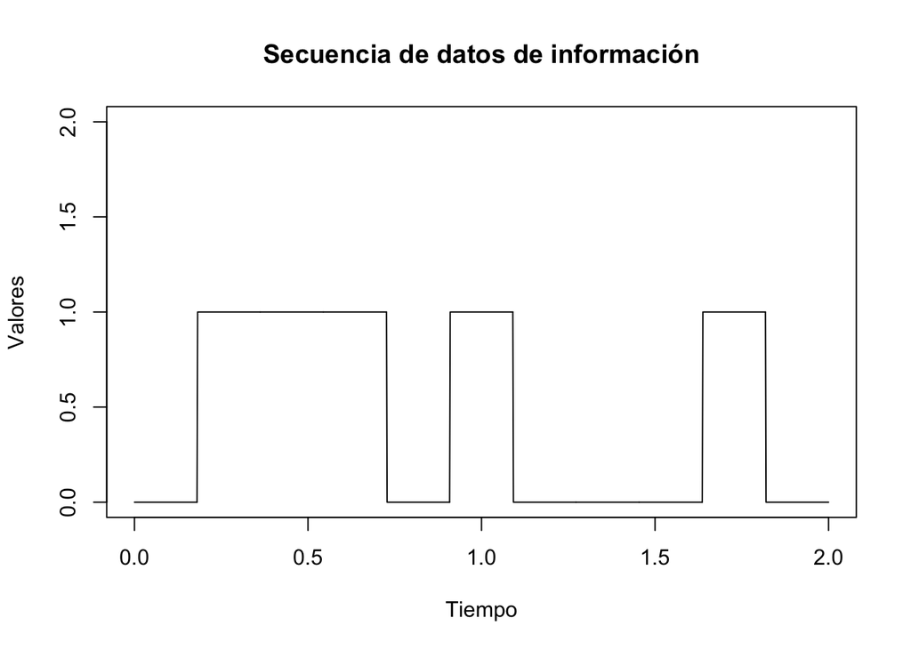

Bits de información. Estos bits serán codifcados por una o más señales analógicas.

```r
# Información original 00110100010
# Representación gráfica
xt <- c(0,1,1,1,0,1,0,0,0,1,0)
bits <- rep(xt, each=100)
time <- seq(0,2, length=length(bits))
plot(time, bits, type = "l", main="Secuencia de datos de información", xlab="Tiempo", ylab="Valores", ylim=c(0,2))
```

Posteriormente codificamos la anterior señal de comunicación usando las siguientes reglas:

- 0 se codifica con un nivel de amplitud $A_1 \cos(2\pi ft)$.
- 1 se codifica con un nivel de amplitud $A_2 \cos(2\pi ft)$.

Note que las amplitudes sirven para codificar la señal, la amplitud incluso puede ser $0$. Ahora programaremos la anterior codificación usando R:

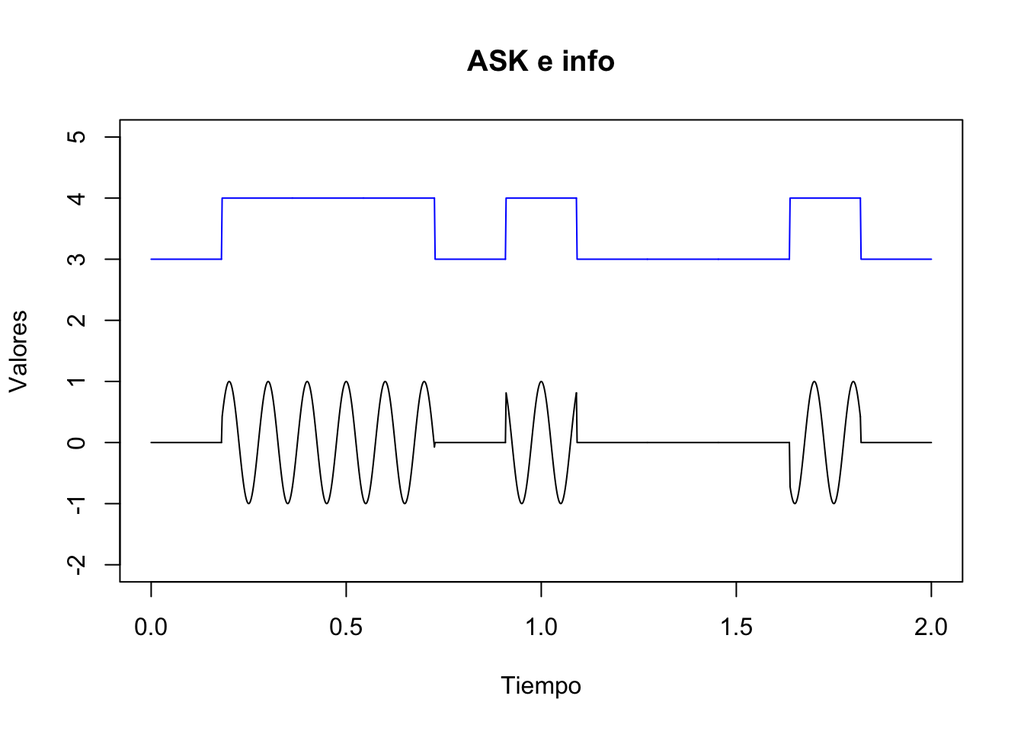

Señal ASK codificada según la regla de arriba y usando amplitudes 0 y $A_1$, la señal ASK de este tipo se llama OOK.

```r
xt <- c(0,1,1,1,0,1,0,0,0,1,0)         # Se generan los códigos
# Ahora se codifica de acuerdo a la regla descrita arriba
bits <- rep(xt, each=100)
time <- seq(0,2, length=length(bits))  # Se genera el tiempo (puede ser cualquiera).
ask <- ifelse(bits==0, 0, cos(20*pi*time)) # Se genera la señal ASK
plot(time,bits+3,type="l",main="ASK e info", xlab="Tiempo", ylab="Valores", ylim=c(-2,5),col="blue")
lines(time, ask)
```

Es importante hacer notar que la regla indica que las amplitudes no deben de ser iguales, por lo tanto la siguiente codificación también es válida:

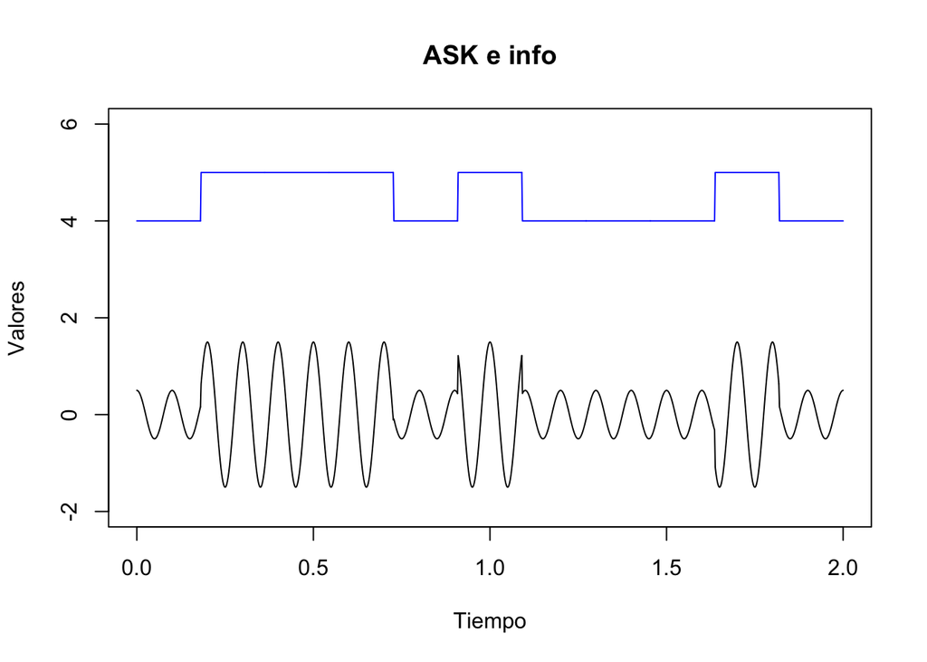

```r
xt <- c(0,1,1,1,0,1,0,0,0,1,0)         # Se generan los códigos
# Ahora se codifica de acuerdo a la regla descrita arriba
bits <- rep(xt, each=100)
time <- seq(0,2, length=length(bits))  # Se genera el tiempo (puede ser cualquiera).
ask <- ifelse(bits==0, 0.5*cos(20*pi*time), 1.5*cos(20*pi*time)) # Se genera la señal ASK
plot(time,bits+4,type="l",main="ASK e info", xlab="Tiempo", ylab="Valores", ylim=c(-2,6),col="blue")
lines(time, ask)
```

## Tareas

Implementar las siguientes codificaciones de señales digitales a analógicas e investigar su aplicación en las redes de comunicaciones inalámbricas: Entrega: miércoles 13 de septiembre de 2023. Atte. Dr Julio César Ramírez Pacheco

- FSK
- PSK